# Išskirčių šalinimas

Edvinas Karenga

4/1/2020

### Pradiniai duomenys

Mėginių skaičius: 35

Išmatuotų metilinimo įverčių skaičius: 475559

### Išskirčių šalinimas

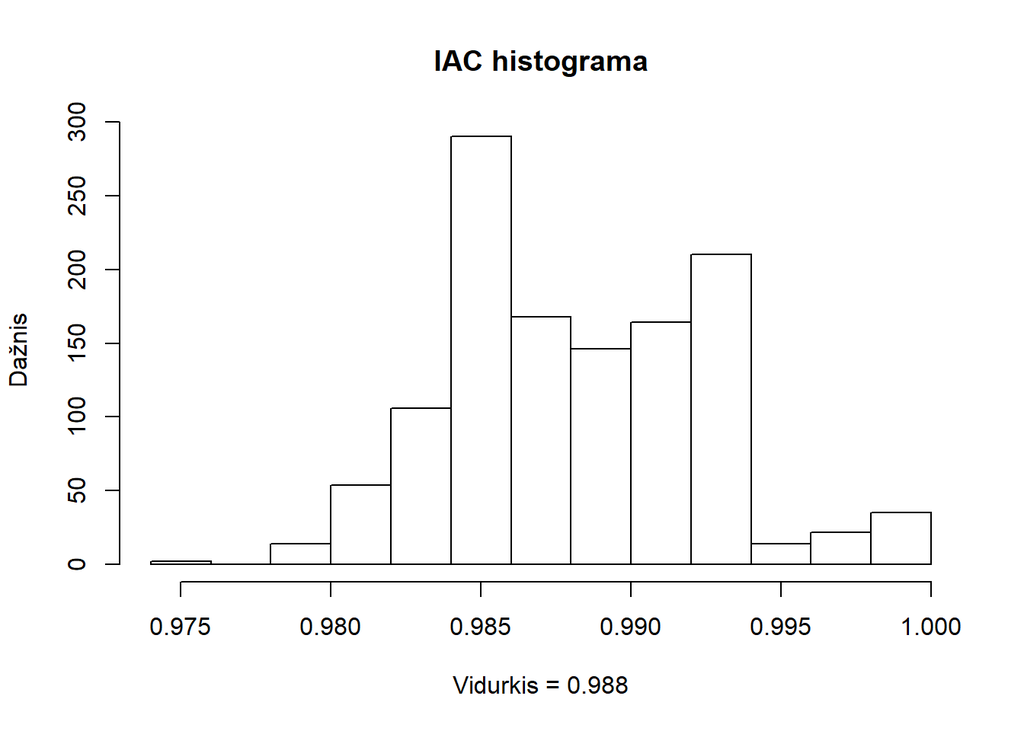

IAC vidurkis duomenų rinkinyje su be pašalintų išskirčių yra 0.988. Abiejuose galuose matomos nedidelės uodegos, kas gali reikšti, kad yra išimčių. Taip pat matosi dvi viršūnės, kas galėtų reikšti, kad mėginiai pasiskirstę į dvi grupes.

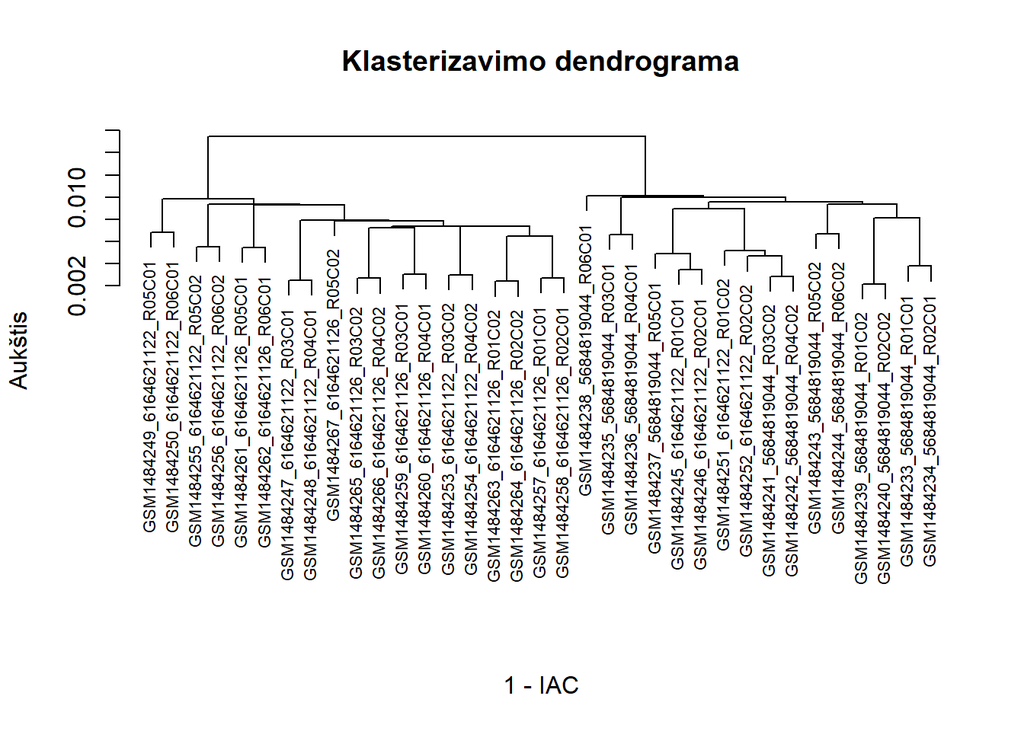

Atlikus hierarchinį klasterizavimą (UPGMA, naudojant 1 - IAC, kaip atstumo dydį), akivaizdžių mėginių, kurie galėtų būti išimtys nesimato. Čia taip pat pastebimas mėginių pasiskirtymas į dvi grupes.

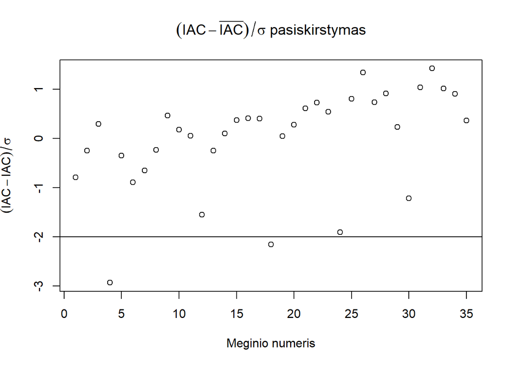

Paskaičiavus IAC vidurkį kiekvienam mėginiui ir nubraižius jų pasiskirtymą matosi du mėginiai išskirtys:

GSM1484236_5684819044_R04C01, GSM1484250_6164621122_R06C01

Pašaliname tuos mėginius ir pakartojame procesą dar 4 kartus.

### Po 4 iteracijų gauti rezultatai

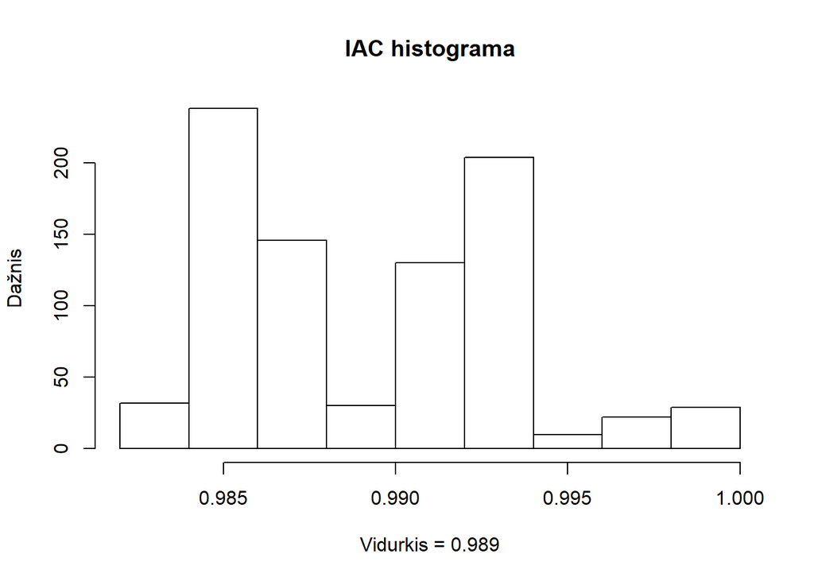

Koreliacijos pasiskirtymo histrogramoje matome, kad nebeliko uodegos kairėje pusėje ir atsirado, ryškus atsiskyrimas tarp dviejų meginių grupių.

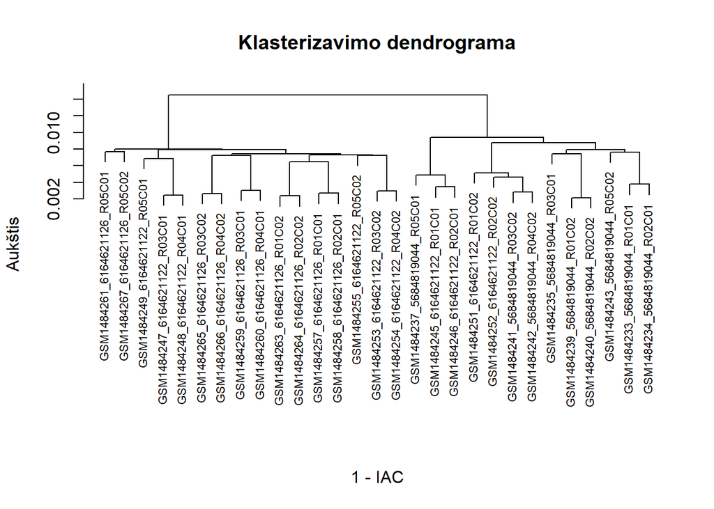

Pagal hierarchinį klasterizavimą mėginių išskirčių nesimato, bet taip pat matosi dvi grupės.

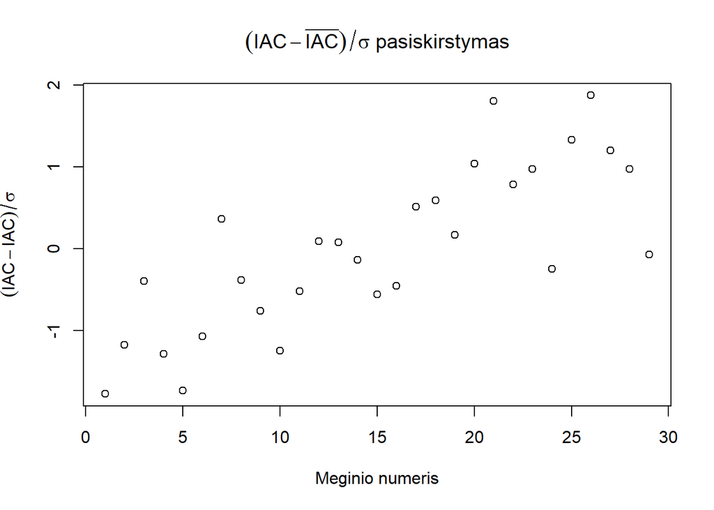

Iš mėginių vidutinės koreliacijos su kitais mėginiais grafiko matome, kad didelių išskirčių nebeliko.

### Galutiniai duomenys

Pašalintų mėginių skaičius: 6

Pašalinti mėginiai: GSM1484236_5684819044_R04C01, GSM1484250_6164621122_R06C01, GSM1484244_5684819044_R06C02, GSM1484256_6164621122_R06C02, GSM1484262_6164621126_R06C01, GSM1484238_5684819044_R06C01

Likęs mėginių skaičius: 29

#### Informacija apie likusius mėginius

| gender | training | Freq |
| --- | --- | --- |
| female | after | 6 |
| male | after | 5 |
| female | before | 10 |
| male | before | 8 |